# McDonald Data Analysis

##### Basic python packages load

```python
#import the required libraries
import numpy as np
import pandas as pd
import matplotlib.pyplot as plt
%matplotlib inline

import seaborn as sns
sns.set(color_codes=True)
```

#### Load the dataset

```python
#load the data from the csv file
McD = pd.read_csv("D:\\Academic Operations\\DSBA - Python\\B + O\\Mcdonald.csv")
```

## Exploratory Data Analysis

##### Let us check if the data has been loaded

```python
McD.head()
```

|  | Category | Item | Serving Size | Calories | Calories from Fat | Total Fat | Total Fat (% Daily Value) | Saturated Fat | Saturated Fat (% Daily Value) | Trans Fat | ... | Carbohydrates | Carbohydrates (% Daily Value) | Dietary Fiber | Dietary Fiber (% Daily Value) | Sugars | Protein | Vitamin A (% Daily Value) | Vitamin C (% Daily Value) | Calcium (% Daily Value) | Iron (% Daily Value) |
| --- | --- | --- | --- | --- | --- | --- | --- | --- | --- | --- | --- | --- | --- | --- | --- | --- | --- | --- | --- | --- | --- |
| 0 | Breakfast | Egg McMuffin | 4.8 oz (136 g) | 300 | 120 | 13.0 | 20 | 5.0 | 25 | 0.0 | ... | 31 | 10 | 4 | 17 | 3 | 17 | 10 | 0 | 25 | 15 |
| 1 | Breakfast | Egg White Delight | 4.8 oz (135 g) | 250 | 70 | 8.0 | 12 | 3.0 | 15 | 0.0 | ... | 30 | 10 | 4 | 17 | 3 | 18 | 6 | 0 | 25 | 8 |
| 2 | Breakfast | Sausage McMuffin | 3.9 oz (111 g) | 370 | 200 | 23.0 | 35 | 8.0 | 42 | 0.0 | ... | 29 | 10 | 4 | 17 | 2 | 14 | 8 | 0 | 25 | 10 |
| 3 | Breakfast | Sausage McMuffin with Egg | 5.7 oz (161 g) | 450 | 250 | 28.0 | 43 | 10.0 | 52 | 0.0 | ... | 30 | 10 | 4 | 17 | 2 | 21 | 15 | 0 | 30 | 15 |
| 4 | Breakfast | Sausage McMuffin with Egg Whites | 5.7 oz (161 g) | 400 | 210 | 23.0 | 35 | 8.0 | 42 | 0.0 | ... | 30 | 10 | 4 | 17 | 2 | 21 | 6 | 0 | 25 | 10 |

5 rows C 24 columns

##### Let us check the types of variables in the data frame.

```python
McD.dtypes
```

```
Category                          object
Item                              object
Serving Size                      object
Calories                           int64
Calories from Fat                  int64
Total Fat                        float64
Total Fat (% Daily Value)          int64
Saturated Fat                    float64
Saturated Fat (% Daily Value)      int64
Trans Fat                        float64
Cholesterol                        int64
Cholesterol (% Daily Value)        int64
Sodium                             int64
Sodium (% Daily Value)             int64
Carbohydrates                      int64
Carbohydrates (% Daily Value)      int64
Dietary Fiber                      int64
Dietary Fiber (% Daily Value)      int64
Sugars                             int64
Protein                            int64
Vitamin A (% Daily Value)          int64
Vitamin C (% Daily Value)          int64
Calcium (% Daily Value)            int64
Iron (% Daily Value)               int64
dtype: object
```

#### Let us check if any value in the data fram is null.

##### We can directly use 'data.info()' instead of using 'data.dtypes'. The code snippet 'data.info()' gives us the complete information about the data frame.

```python
#to obtain the information on the dataset
McD.info()
```

```
<class 'pandas.core.frame.DataFrame'>
RangeIndex: 260 entries, 0 to 259
Data columns (total 24 columns):
Category                         260 non-null object
Item                             260 non-null object
Serving Size                     260 non-null object
Calories                         260 non-null int64
Calories from Fat                260 non-null int64
Total Fat                        260 non-null float64
Total Fat (% Daily Value)        260 non-null int64
Saturated Fat                    260 non-null float64
Saturated Fat (% Daily Value)    260 non-null int64
Trans Fat                        260 non-null float64
Cholesterol                      260 non-null int64
Cholesterol (% Daily Value)      260 non-null int64
Sodium                           260 non-null int64
Sodium (% Daily Value)           260 non-null int64
Carbohydrates                    260 non-null int64
Carbohydrates (% Daily Value)    260 non-null int64
Dietary Fiber                    260 non-null int64
Dietary Fiber (% Daily Value)    260 non-null int64
Sugars                           260 non-null int64
Protein                          260 non-null int64
Vitamin A (% Daily Value)        260 non-null int64
Vitamin C (% Daily Value)        260 non-null int64
Calcium (% Daily Value)          260 non-null int64
Iron (% Daily Value)             260 non-null int64
dtypes: float64(3), int64(18), object(3)
memory usage: 48.8+ KB
```

There is no null values present in the dataset.

```python
#get the number of rows and columns
row, col = McD.shape
print("There are total {}".format(row), "rows and {}".format(col), "columns in the dataset")
```

```
There are total 260 rows and 24 columns in the dataset
```

### Q1: Plot graphically which food categories have the highest and lowest varieties.

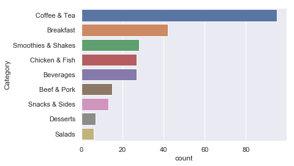

```python
#plot food category vs varieties to get those categories that have the highest and lowest varieties
sns.countplot(y="Category", data=McD, order = McD['Category'].value_counts().index)
```

From the above count plot, we find out:

##### 1. Max Varieties - Coffee & Tea

##### 2. Min Varieties - Salads

### Q2. Which all variables have an outlier?

```python
#to see the outliers we need to use boxplots
McD.describe(include = 'all')
```

|  | Category | Item | Serving Size | Calories | Calories from Fat | Total Fat | Total Fat (% Daily Value) | Saturated Fat | Saturated Fat (% Daily Value) | Trans Fat | ... | Carbohydrates | Carbohydrates (% Daily Value) | Dietary Fiber | Dietary Fiber (% Daily Value) | Sugars | Protein | Vitamin A (% Daily Value) | Vitamin C (% Daily Value) | Calcium (% Daily Value) | Iron (% Daily Value) |
| --- | --- | --- | --- | --- | --- | --- | --- | --- | --- | --- | --- | --- | --- | --- | --- | --- | --- | --- | --- | --- | --- |
| count | 260 | 260 | 260 | 260.000000 | 260.000000 | 260.000000 | 260.000000 | 260.000000 | 260.000000 | 260.000000 | ... | 260.000000 | 260.000000 | 260.000000 | 260.000000 | 260.000000 | 260.000000 | 260.000000 | 260.000000 | 260.000000 | 260.000000 |
| unique | 9 | 260 | 107 | NaN | NaN | NaN | NaN | NaN | NaN | NaN | ... | NaN | NaN | NaN | NaN | NaN | NaN | NaN | NaN | NaN | NaN |
| top | Coffee & Tea | Bacon, Egg & Cheese Bagel with Egg Whites | 16 fl oz cup | NaN | NaN | NaN | NaN | NaN | NaN | NaN | ... | NaN | NaN | NaN | NaN | NaN | NaN | NaN | NaN | NaN | NaN |
| freq | 95 | 1 | 45 | NaN | NaN | NaN | NaN | NaN | NaN | NaN | ... | NaN | NaN | NaN | NaN | NaN | NaN | NaN | NaN | NaN | NaN |
| mean | NaN | NaN | NaN | 368.269231 | 127.096154 | 14.165385 | 21.815385 | 6.007692 | 29.965385 | 0.203846 | ... | 47.346154 | 15.780769 | 1.630769 | 6.530769 | 29.423077 | 13.338462 | 13.426923 | 8.534615 | 20.973077 | 7.734615 |
| std | NaN | NaN | NaN | 240.269886 | 127.875914 | 14.205998 | 21.885199 | 5.321873 | 26.639209 | 0.429133 | ... | 28.252232 | 9.419544 | 1.567717 | 6.307057 | 28.679797 | 11.426146 | 24.366381 | 26.345542 | 17.019953 | 8.723263 |
| min | NaN | NaN | NaN | 0.000000 | 0.000000 | 0.000000 | 0.000000 | 0.000000 | 0.000000 | 0.000000 | ... | 0.000000 | 0.000000 | 0.000000 | 0.000000 | 0.000000 | 0.000000 | 0.000000 | 0.000000 | 0.000000 | 0.000000 |
| 25% | NaN | NaN | NaN | 210.000000 | 20.000000 | 2.375000 | 3.750000 | 1.000000 | 4.750000 | 0.000000 | ... | 30.000000 | 10.000000 | 0.000000 | 0.000000 | 5.750000 | 4.000000 | 2.000000 | 0.000000 | 6.000000 | 0.000000 |
| 50% | NaN | NaN | NaN | 340.000000 | 100.000000 | 11.000000 | 17.000000 | 5.000000 | 24.000000 | 0.000000 | ... | 44.000000 | 15.000000 | 1.000000 | 5.000000 | 17.500000 | 12.000000 | 8.000000 | 0.000000 | 20.000000 | 4.000000 |
| 75% | NaN | NaN | NaN | 500.000000 | 200.000000 | 22.250000 | 35.000000 | 10.000000 | 48.000000 | 0.000000 | ... | 60.000000 | 20.000000 | 3.000000 | 10.000000 | 48.000000 | 19.000000 | 15.000000 | 4.000000 | 30.000000 | 15.000000 |
| max | NaN | NaN | NaN | 1880.000000 | 1060.000000 | 118.000000 | 182.000000 | 20.000000 | 102.000000 | 2.500000 | ... | 141.000000 | 47.000000 | 7.000000 | 28.000000 | 128.000000 | 87.000000 | 170.000000 | 240.000000 | 70.000000 | 40.000000 |

11 rows C 24 columns

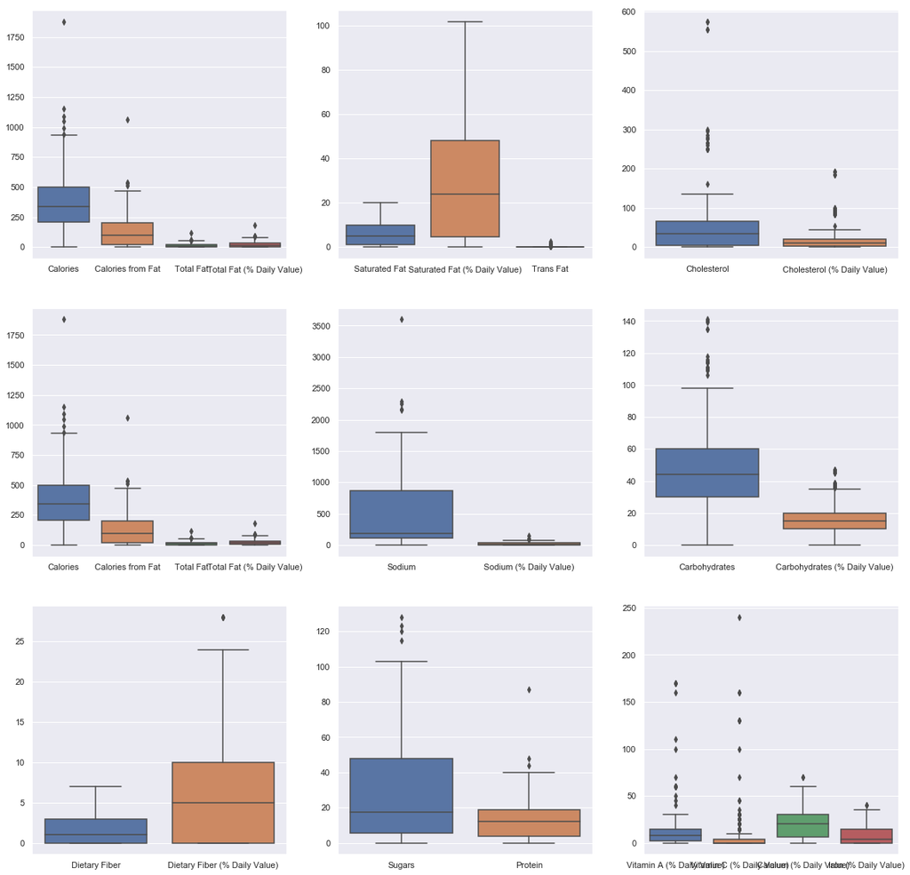

```python
fig, axes = plt.subplots(nrows=3,ncols=3)
fig.set_size_inches(20, 20)
a = sns.boxplot(data=McD[['Calories','Calories from Fat','Total Fat','Total Fat (% Daily Value)']] ,
                orient = "v" , ax=axes[0][0])

b = sns.boxplot(data=McD[['Saturated Fat','Saturated Fat (% Daily Value)' ,'Trans Fat']],
                orient = "v" , ax=axes[0][1])

c = sns.boxplot(data=McD[['Cholesterol','Cholesterol (% Daily Value)']] ,
                orient = "v" , ax=axes[0][2])

d = sns.boxplot(data=McD[['Calories','Calories from Fat','Total Fat','Total Fat (% Daily Value)']] ,
                orient = "v" , ax=axes[1][0])


e = sns.boxplot(data=McD[['Sodium','Sodium (% Daily Value)']]
                , orient = "v" , ax=axes[1][1])


f = sns.boxplot(data=McD[['Carbohydrates', 'Carbohydrates (% Daily Value)']]
                , orient = "v" , ax=axes[1][2])


g = sns.boxplot(data=McD[['Dietary Fiber', 'Dietary Fiber (% Daily Value)']]
                , orient = "v" , ax=axes[2][0])


h = sns.boxplot(data=McD[['Sugars', 'Protein']]
                , orient = "v" , ax=axes[2][1])


i = sns.boxplot(data=McD[['Vitamin A (% Daily Value)', 'Vitamin C (% Daily Value)', 'Calcium (% Daily Value)', 'Iron (% Daily Value)']]
                , orient = "v" , ax=axes[2][2])

plt.show()
```

##### The list of all the variables in the McDonalds dataset that have outliers are--

Calories,Calories from Fat,Total Fat,Total Fat (% Daily Value), Trans Fat, Cholesterol, Cholesterol (% Daily Value), Sodium, Sodium (% Daily Value), Carbohydrates, Carbohydrates (% Daily Value), Dietary Fiber (% Daily Value), Sugars, Protein, Vitamin A (% Daily Value), Vitamin C (% Daily Value), Calcium (% Daily Value), Iron (% Daily Value)

### Q3. Which variables have the Highest correlation. Plot them and find out the value ?

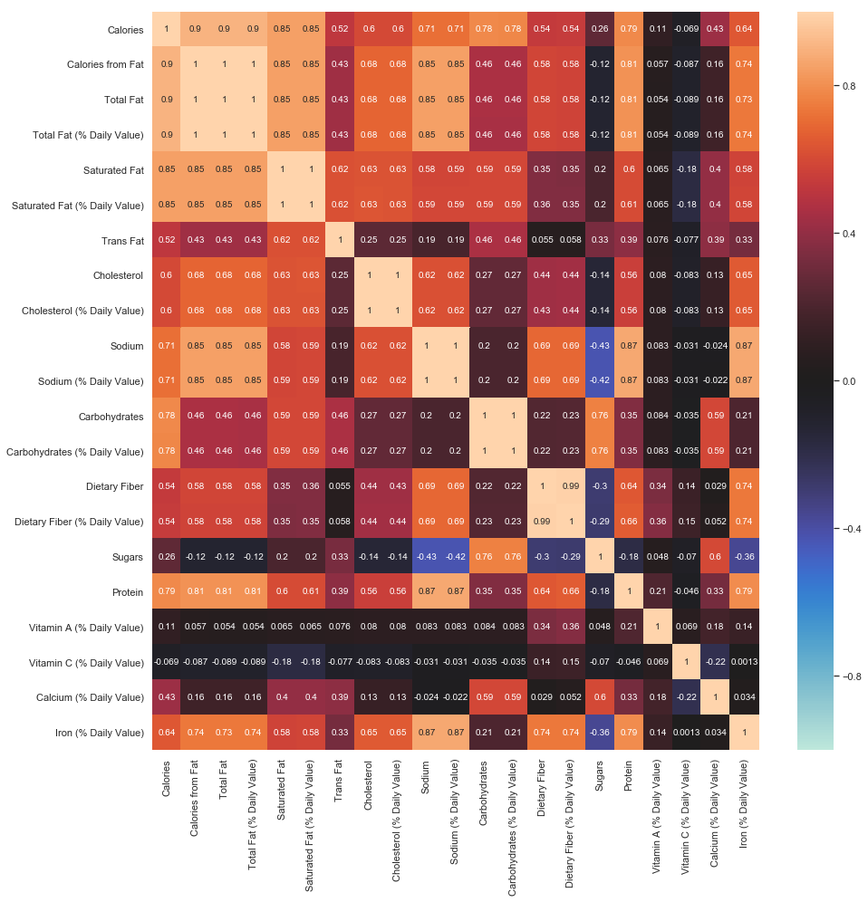

```python
#to obtain the correlation of the different variables in McDonalds dataset
cor=McD.corr()
plt.figure(figsize=(15, 15))
sns.heatmap(cor,annot = True, vmin=-1, vmax=1, center= 0)
```

##### As per the heatmap above and the correlation matrix, the variable with the highest correlation is

b" Calories from Fat - Total Fat : 0.99

b" Total Fat Daily Value.- Total Fat : 0.99

b" Saturated.Fat-Saturated.Fat Daily Value : 0.99

b" Cholesterol-Cholesterol Daily Value : 0.99

### Q4. Which category contributes to the maximum % of Cholesterol in a diet (% daily value)?

```python
McD.groupby('Category').sum()['Cholesterol (% Daily Value)'].sort_values(ascending = False)
```

```
Category
Breakfast             2140
Coffee & Tea           891
Chicken & Fish         681
Beef & Pork            434
Smoothies & Shakes     412
Salads                 104
Snacks & Sides          81
Desserts                34
Beverages                5
Name: Cholesterol (% Daily Value), dtype: int64
```

##### 'Breakfast' category contributes to the maximum %Cholesterol in a diet based on (% daily value of Cholesterol) as shown above.

### Q5. Which item contributes maximum to the Sodium intake?

```python
McD.groupby('Item').sum()['Sodium'].sort_values(ascending = False)
```

```
Item
Chicken McNuggets (40 piece)                                    3600
Big Breakfast with Hotcakes and Egg Whites (Large Biscuit)      2290
Big Breakfast with Hotcakes (Large Biscuit)                     2260
Big Breakfast with Hotcakes and Egg Whites (Regular Biscuit)    2170
Big Breakfast with Hotcakes (Regular Biscuit)                   2150
Chicken McNuggets (20 piece)                                    1800
Bacon Clubhouse Crispy Chicken Sandwich                         1720
Big Breakfast with Egg Whites (Large Biscuit)                   1700
Big Breakfast (Large Biscuit)                                   1680
Big Breakfast with Egg Whites (Regular Biscuit)                 1590
Big Breakfast (Regular Biscuit)                                 1560
Bacon Clubhouse Grilled Chicken Sandwich                        1560
Premium McWrap Chicken & Bacon (Crispy Chicken)                 1540
Steak, Egg & Cheese Bagel                                       1510
Bacon, Egg & Cheese Bagel with Egg Whites                       1480
Bacon, Egg & Cheese Bagel                                       1480
Premium McWrap Southwest Chicken (Crispy Chicken)               1480
Steak & Egg Biscuit (Regular Biscuit)                           1470
Bacon Clubhouse Burger                                          1470
Quarter Pounder with Bacon & Cheese                             1440
Bacon, Egg & Cheese Biscuit with Egg Whites (Large Biscuit)     1420
Bacon, Egg & Cheese Biscuit (Large Biscuit)                     1410
Premium Crispy Chicken Club Sandwich                            1410
Premium Crispy Chicken Ranch BLT Sandwich                       1400
Premium McWrap Chicken & Bacon (Grilled Chicken)                1370
Premium McWrap Chicken & Ranch (Crispy Chicken)                 1340
Sausage, Egg & Cheese McGriddles with Egg Whites                1320
Premium McWrap Southwest Chicken (Grilled Chicken)              1320
Sausage, Egg & Cheese McGriddles                                1320
Bacon, Egg & Cheese Biscuit (Regular Biscuit)                   1300
                                                                ...
Regular Iced Coffee (Small)                                       35
Sprite (Small)                                                    30
Dr Pepper (Child)                                                 30
Sprite (Child)                                                    25
Kids Ice Cream Cone                                               20
Diet Coke (Medium)                                                20
Diet Coke (Child)                                                 15
Iced Tea (Large)                                                  15
```

[output cut: 8 more lines]

```
Coca-Cola Classic (Large)                                          5
Coca-Cola Classic (Medium)                                         5
Minute Maid Orange Juice (Large)                                   5
Sweet Tea (Child)                                                  5
Iced Tea (Child)                                                   5
Apple Slices                                                       0
Coffee (Large)                                                     0
Dasani Water Bottle                                                0
Coffee (Small)                                                     0
Coffee (Medium)                                                    0
Coca-Cola Classic (Small)                                          0
Minute Maid Orange Juice (Medium)                                  0
Minute Maid Orange Juice (Small)                                   0
Coca-Cola Classic (Child)                                          0
Name: Sodium, Length: 260, dtype: int64
```

##### From the above results, Chicken McNuggets(40 piece)' contributes to maximum Sodium intake (3600).

Top 5 items with maximum sodium value:

1. Chicken McNuggets (40 piece) 3600
2. Big Breakfast with Hotcakes and Egg Whites (Large Biscuit) 2290
3. Big Breakfast with Hotcakes (Large Biscuit) 2260
4. Big Breakfast with Hotcakes and Egg Whites (Regular Biscuit) 2170
5. Big Breakfast with Hotcakes (Regular Biscuit) 2150

### Q6. Which 4 food items contains the most amount of Saturated Fat?

```python
McD.groupby('Item').sum()['Saturated Fat'].sort_values(ascending = False)
```

```
Item
Big Breakfast with Hotcakes (Large Biscuit)                     20.0
Chicken McNuggets (40 piece)                                    20.0
McFlurry with M&Mbs Candies (Medium)                            20.0
FrappC) Chocolate Chip (Large)                                   20.0
Big Breakfast with Hotcakes (Regular Biscuit)                   19.0
Double Quarter Pounder with Cheese                              19.0
Big Breakfast (Large Biscuit)                                   18.0
FrappC) Caramel (Large)                                          17.0
FrappC) Mocha (Large)                                            17.0
Big Breakfast (Regular Biscuit)                                 17.0
FrappC) Chocolate Chip (Medium)                                  17.0
Big Breakfast with Hotcakes and Egg Whites (Large Biscuit)      16.0
Big Breakfast with Hotcakes and Egg Whites (Regular Biscuit)    16.0
Steak & Egg Biscuit (Regular Biscuit)                           16.0
McFlurry with Reese's Peanut Butter Cups (Medium)               15.0
Chocolate Shake (Large)                                         15.0
Shamrock Shake (Large)                                          15.0
FrappC) Caramel (Medium)                                         15.0
Sausage Biscuit with Egg (Large Biscuit)                        15.0
Vanilla Shake (Large)                                           15.0
Strawberry Shake (Large)                                        15.0
Bacon Clubhouse Burger                                          15.0
FrappC) Mocha (Medium)                                           14.0
Bacon, Egg & Cheese Biscuit (Large Biscuit)                     14.0
Sausage Biscuit with Egg (Regular Biscuit)                      14.0
FrappC) Chocolate Chip (Small)                                   14.0
Big Breakfast with Egg Whites (Large Biscuit)                   14.0
Big Breakfast with Egg Whites (Regular Biscuit)                 14.0
McFlurry with M&Mbs Candies (Small)                             14.0
Bacon, Egg & Cheese Biscuit (Regular Biscuit)                   13.0
                                                                ...
Coca-Cola Classic (Small)                                        0.0
Coffee (Large)                                                   0.0
Coffee (Medium)                                                  0.0
Coffee (Small)                                                   0.0
Dasani Water Bottle                                              0.0
Nonfat Hazelnut Latte (Small)                                    0.0
Diet Coke (Child)                                                0.0
Diet Coke (Large)                                                0.0
```

[output cut: 8 more lines]

```
Nonfat Caramel Latte (Large)                                     0.0
Nonfat Caramel Latte (Medium)                                    0.0
Nonfat Caramel Latte (Small)                                     0.0
Dr Pepper (Medium)                                               0.0
Dr Pepper (Small)                                                0.0
Minute Maid 100% Apple Juice Box                                 0.0
Fat Free Chocolate Milk Jug                                      0.0
Mango Pineapple Smoothie (Small)                                 0.0
Nonfat French Vanilla Latte (Large)                              0.0
Nonfat French Vanilla Latte (Medium)                             0.0
Nonfat French Vanilla Latte (Small)                              0.0
Nonfat Hazelnut Latte (Large)                                    0.0
Nonfat Hazelnut Latte (Medium)                                   0.0
Coca-Cola Classic (Large)                                        0.0
Name: Saturated Fat, Length: 260, dtype: float64
```

##### From the above results, below are the 4 food items which contains the most amount of Saturated Fat:

1. Big Breakfast with Hotcakes (Large Biscuit) 20.0
2. Chicken McNuggets (40 piece) 20.0
3. McFlurry with M&Mbs Candies (Medium) 20.0
4. FrappC) Chocolate Chip (Large) 20.0